# Summary Regression Models Course

Desiré De Waele

17 maart 2016

# Plotting Linear Model and Residuals

Example of linear regression fit, and the residuals. Code is hidden for now.

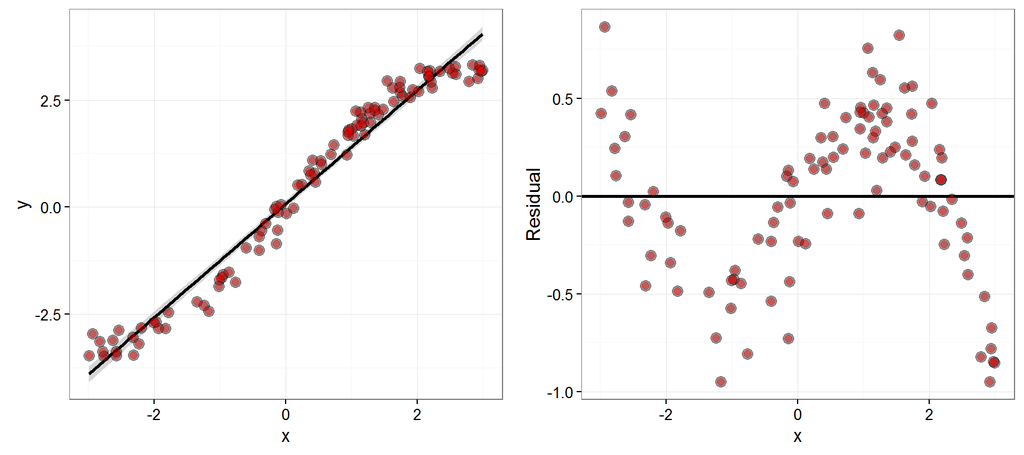

The same code is used on the diamond dataset of the UsingR package, the data used throughout this summary. The plots below show the relation between carats and price, the linear model fit and its residuals.

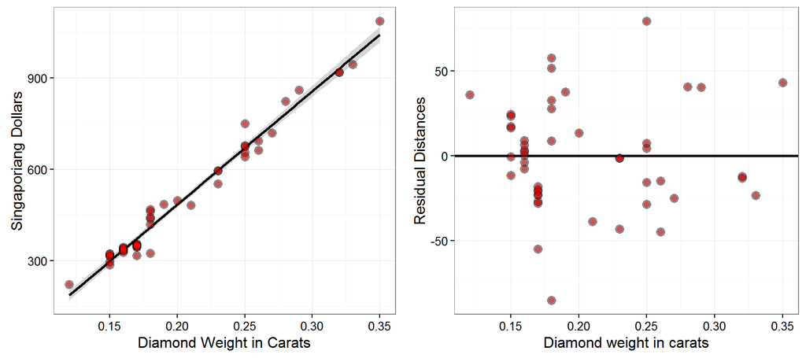

```r
library(ggplot2); library(UsingR); library(gridExtra); data(diamond)
y <- diamond$price; x <- diamond$carat; n <- length(y)

g1 = ggplot(data.frame(x = x, y = y), aes(x = x, y = y)) + theme_bw()
g1 = g1 + geom_smooth(method = "lm", colour = "black")
g1 = g1 + geom_point(size = 3, colour = "black", alpha = 0.4)
g1 = g1 + geom_point(size = 2, colour = "red", alpha = 0.4)
g1 = g1 + labs(x = "Diamond Weight in Carats", y = "Singaporiang Dollars")

g2 = ggplot(data.frame(x = x, y = resid(lm(y ~ x))), aes(x = x, y = y)) + theme_bw()
g2 = g2 + geom_hline(yintercept = 0, size = 1);
g2 = g2 + geom_point(size = 3, colour = "black", alpha = 0.4)
g2 = g2 + geom_point(size = 2, colour = "red", alpha = 0.4)
g2 = g2 + labs(x = "Diamond weight in carats", y = "Residual Distances")
grid.arrange(g1, g2, ncol=2)
```

# Linear Model

## Coefficients

Formulas for variance, covariance and correlation.

$\begin{aligned} &S^2 = \frac{1}{n-1} \sum_{i=1}^n (X_i - \bar X)^2 = \frac{1}{n-1} \left( \sum_{i=1}^n X_i^2 - n \bar X ^ 2 \right)\\ &Cov(X, Y) = \frac{1}{n-1}\sum_{i=1}^n (X_i - \bar X) (Y_i - \bar Y) = \frac{1}{n-1}\left( \sum_{i=1}^n X_i Y_i - n \bar X \bar Y\right)\\ &Cor(X, Y) = \frac{Cov(X, Y)}{S_x S_y} \end{aligned}$

Formulas for linear model fit, slope and intercept.

$\begin{aligned} &Y_i = \beta_0 + \beta_1 X_i + \epsilon_i | \epsilon_i \sim N(0, \sigma^2)\\ &\hat \beta_1 = Cor(Y, X) \frac{Sd(Y)}{Sd(X)}\\ &\hat \beta_0 = \bar Y - \hat \beta_1 \bar X\\ \end{aligned}$

Calculating coefficients of the linear fit by hand and with lm function.

```r
y <- diamond$price; x <- diamond$carat; n <- length(y)
beta1 <- cor(y, x) * sd(y) / sd(x)
beta0 <- mean(y) - beta1 * mean(x)
fit <- lm(y ~ x)
rbind(c(beta0, beta1), coef(fit))
```

```
##      (Intercept)        x
## [1,]   -259.6259 3721.025
## [2,]   -259.6259 3721.025
```

## Outcome Estimates

By hand and with predict function.

```r
y <- diamond$price; x <- diamond$carat; n <- length(y)
fit <- lm(y ~ x)
newx <- c(0.16, 0.27, 0.34)
byhand <- coef(fit)[1] + coef(fit)[2] * newx
byfunction <- predict(fit, newdata = data.frame(x = newx))
rbind(byhand, byfunction)
```

```
##                   1        2        3
## byhand     335.7381 745.0508 1005.523
## byfunction 335.7381 745.0508 1005.523
```

# Residuals

## Calculation

By hand and with resid function.

```r
y <- diamond$price; x <- diamond$carat; n <- length(y)
fit <- lm(y ~ x)
byhand <- y - predict(fit)
byfunction <- resid(fit)
rbind(sort(byhand)[1:3], sort(byfunction)[1:3])
```

```
##              4        27        18
## [1,] -85.15857 -54.94832 -44.84055
## [2,] -85.15857 -54.94832 -44.84055
```

## Residual Variation

Formula for residual variation. $\begin{aligned} &\hat \sigma^2 = \frac{\sum_{i=1}^n e_i^2}{n-2}\\ \end{aligned}$

Calculating the residual variation with formula, or by retrieval of lm function.

```r
y <- diamond$price; x <- diamond$carat; n <- length(y)
fit <- lm(y ~ x)
byhand <- sqrt(sum(resid(fit)^2) / (n - 2))
byformula <- summary(fit)$sigma
rbind(byhand, byformula)
```

```
##               [,1]
## byhand    31.84052
## byformula 31.84052
```

## Regression Variation

The total variation sums the residual variation and the regression variation. The latter is the variance explained by the linear model. R squared is the regression variation divided by the total variation, and estimates the power of the linear model.

$\begin{aligned} &\sum_{i=1}^n (Y_i - \bar Y)^2 = \sum_{i=1}^n (Y_i - \hat Y_i)^2 + \sum_{i=1}^n (\hat Y_i - \bar Y)^2\\ &r^2 = \frac{\sum_{i=1}^n (\hat Y_i - \bar Y)^2}{\sum_{i=1}^n (Y_i - \bar Y)^2} = Cor(X, Y)^2 \end{aligned}$

# Intervals

## Confidence Intervals for Coefficients

Formulas for standard errors of both the slope and the intercept. $\begin{aligned} &\sigma_{\hat \beta_1}^2 = Var(\hat \beta_1) = \frac{\sigma^2}{\sum_{i=1}^n (X_i - \bar X)^2}\\ &\sigma_{\hat \beta_0}^2 = Var(\hat \beta_0) = \left(\frac{1}{n} + \frac{\bar X^2}{\sum_{i=1}^n (X_i - \bar X)^2 }\right)\sigma^2\\ \end{aligned}$

Setting up a coefficient table by hand…

```r
y <- diamond$price; x <- diamond$carat; n <- length(y)
beta1 <- cor(y, x) * sd(y) / sd(x)
beta0 <- mean(y) - beta1 * mean(x)
e <- y - beta0 - beta1 * x # Residuals
sigma <- sqrt(sum(e^2) / (n-2)) # Residual variation
ssx <- sum((x - mean(x))^2) # Denominator of coefficient standard errors

# Standard errors coefficients
seBeta0 <- (1 / n + mean(x) ^ 2 / ssx) ^ .5 * sigma
seBeta1 <- sigma / sqrt(ssx)
# t-statistics when H0: beta mean = 0
tBeta0 <- beta0 / seBeta0; tBeta1 <- beta1 / seBeta1
# Calculating p-values
pBeta0 <- 2 * pt(abs(tBeta0), df = n - 2, lower.tail = FALSE)
pBeta1 <- 2 * pt(abs(tBeta1), df = n - 2, lower.tail = FALSE)

# Setting up a table
table <- rbind(c(beta0, seBeta0, tBeta0, pBeta0), c(beta1, seBeta1, tBeta1, pBeta1))
colnames(table) <- c("Estimate", "Std. Error", "t value", "Pr(>|t|)")
rownames(table) <- c("(Intercept)", "x"); table
```

```
##              Estimate Std. Error   t value     Pr(>|t|)
## (Intercept) -259.6259   17.31886 -14.99094 2.523271e-19
## x           3721.0249   81.78588  45.49715 6.751260e-40
```

…or by retrieval of the lm function.

```r
y <- diamond$price; x <- diamond$carat; n <- length(y)
fit <- lm(y ~ x);
summary(fit)$coefficients
```

```
##              Estimate Std. Error   t value     Pr(>|t|)
## (Intercept) -259.6259   17.31886 -14.99094 2.523271e-19
## x           3721.0249   81.78588  45.49715 6.751260e-40
```

### Calculation of slope confidence interval

```r
y <- diamond$price; x <- diamond$carat; n <- length(y)
fit <- lm(y ~ x)
sumCoef <- summary(fit)$coefficients
# Calculating 95% interval for the price increase per 0.1 carat
(sumCoef[2,1] + c(-1, 1) * qt(.975, df = fit$df) * sumCoef[2, 2]) / 10
```

```
## [1] 355.6398 388.5651
```

## Confidence Interval for Linear Model

Formula for standard error of the confidence interval at a given point $x_0$.

$\begin{aligned} SE_{confidence} \ \text{at} \ x_0 &= \hat \sigma\sqrt{\frac{1}{n} + \frac{(x_0 - \bar X)^2}{\sum_{i=1}^n (X_i - \bar X)^2}}\\ \end{aligned}$ Calculating the confidence interval at the mean of x, by hand and with predict function.

```r
yhat <- fit$coef[1] + fit$coef[2] * mean(x)
confByHand <- yhat + c(-1, 1) * qt(.975, df = fit$df) * summary(fit)$sigma / sqrt(length(y))
confFormula <- predict(fit, newdata = data.frame(x = mean(x)), interval = ("confidence"))

table <- rbind(c(yhat, confByHand), confFormula)
rownames(table) <- c("Confidence by hand", "Confidence by formula")
colnames(table) <- c("Estimate", "Lower limit", "Upper limit"); table
```

```
##                       Estimate Lower limit Upper limit
## Confidence by hand    500.0833    490.8325    509.3342
## Confidence by formula 500.0833    490.8325    509.3342
```

## Prediction Interval for Outcome Estimates

Formula for standard error of the prediction interval at a given point $x_0$.

$\begin{aligned} SE_{prediction} \ \text{at} \ x_0 &= \hat \sigma\sqrt{1 + \frac{1}{n} + \frac{(x_0 - \bar X)^2}{\sum_{i=1}^n (X_i - \bar X)^2}}\\ \end{aligned}$ Calculating the prediction interval at the mean of x, by hand and with predict function.

```r
yhat <- fit$coef[1] + fit$coef[2] * mean(x)
predByHand <- yhat + c(-1, 1) * qt(.975, df = fit$df) * summary(fit)$sigma * sqrt(1 + 1/length(y))
predFormula <- predict(fit, newdata = data.frame(x = mean(x)), interval = ("prediction"))

table <- rbind(c(yhat, predByHand), predFormula)
rownames(table) <- c("Prediction by hand", "Prediction by formula")
colnames(table) <- c("Estimate", "Lower limit", "Upper limit"); table
```

```
##                       Estimate Lower limit Upper limit
## Prediction by hand    500.0833    435.3275    564.8392
## Prediction by formula 500.0833    435.3275    564.8392
```

Example plot with confidence and prediction intervals, to help interpret them.

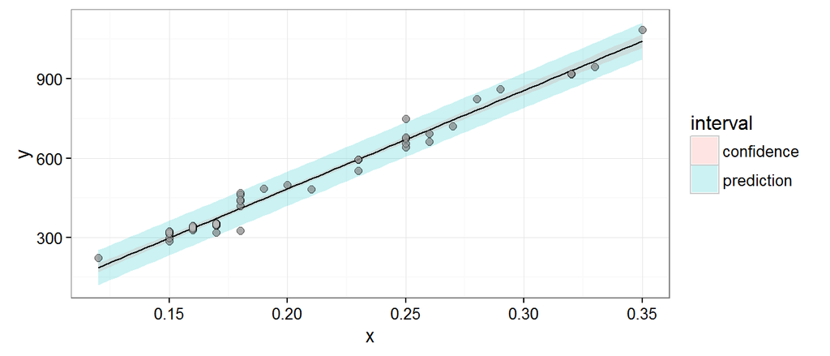